# Missing Data Lab Key

# Data used

Bike Lanes Dataset: BikeBaltimore is the Department of Transportation’s bike program. The data is from http://data.baltimorecity.gov/Transportation/Bike-Lanes/xzfj-gyms

You can Download as a CSV in your current working directory. Note its also available at: https://sisbid.github.io/Data-Wrangling/data/Bike_Lanes.csv

If you haven’t installed `naniar` yet, you will need to use: `install.packages("naniar")` first.

```r
library(tidyverse)
library(naniar)

bike <-read_csv("https://sisbid.github.io/Data-Wrangling/data/Bike_Lanes.csv")
```

1. Use the `is.na()` and `any()` functions to check if the bike `dateInstalled` variable has any `NA` values. Hint: You first need to `pull` out the vector version of this variable to use the `is.na()` function.

```r
bike %>%
  pull(dateInstalled) %>%
  is.na() %>%
  any()
```

```
## [1] FALSE
```

2. Filter rows of bike, so that only rows remain that do NOT have missing values for the `route` variable, using `drop_na`. Assign this to the object `have_route.`

```r
have_rout <- bike %>% drop_na(route)
```

3. Use `naniar` to make a visual of the amount of data missing for each variable of `bike` (use `gg_miss_var()`). Check out more about this package here: https://www.njtierney.com/post/2018/06/12/naniar-on-cran/

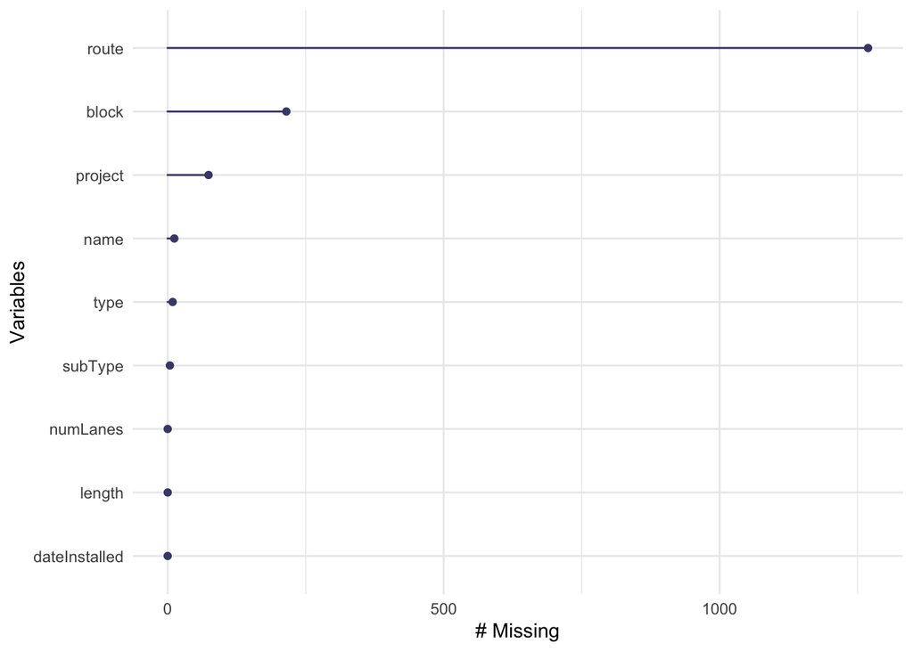

```r
gg_miss_var(bike)
```

4. What percentage of the `subType` variable is complete of `bike` ? Hint: use another `naniar` function.

```r
pull(bike, subType) %>% pct_complete() # this
```

```
## [1] 99.75475
```

```r
miss_var_summary(bike) # or this
```

```
## # A tibble: 9 × 3
##   variable      n_miss pct_miss
##   <chr>          <int>    <num>
## 1 route           1269   77.8
## 2 block            215   13.2
## 3 project           74    4.54
## 4 name              12    0.736
## 5 type               9    0.552
## 6 subType            4    0.245
## 7 numLanes           0    0
## 8 length             0    0
## 9 dateInstalled      0    0
```